# MATH6200

Dennis E. Cabais

2022-03-13

# About

*Why should you learn R?*

It’s…

- totally free!
- open-source
- a scripting language (reproducible and transparent)
- an established tool with tons of tutorials and help pages
- an amazing and inclusive community

## First steps

R = programming language that can be written directly into your computer’s console/terminal

R-Studio = integrated development environment (IDE) with lots of features

Almost all R-users have both installed

### R-Studio

Four panels:

Top-left: scripting panel – write and save code (may only open when you open a new file)

Bottom-left: console panel – input/output that won’t be saved

Top-right: environment panel – dataframes, variables (and sometimes has other features too, depending on what you’re working with)

Bottom-right: install and update packages, preview plots, read help files, and some other features

### R script (.R)

File -> New File -> R Script

- simple: only code
- write lines of code in the order they are meant to be run
- run each line by clicking that line and pressing Control + R (on Windows) or Cmd + Enter (on Mac)
- output shows below, in console panel (number in bracket shows amount of output if there is more than one line)
- Try it out: 5 + 5
- comments that are not read as code: #

### R-Markdown file (.Rmd)

File -> New File -> R Markdown

- R-Markdown: more complex, both code and text, can also include images and some basic formatting (## for headers)
- YAML information at top:
- text in whitespace = text (unlike in an R script)
  - keep notes or leave a record of your decisions
- code needs a code chunk – type it with three backticks or use Insert in the top bar and select R

Run code: - press Control + R (on Windows) or Cmd + Enter (on Mac) with your cursor in the line - use green right-pointing arrow at right edge of code block - arrow with line under it -> runs all code chunks above (but not the current one)

Output: - directly below code block in preview window

- Can also use (#) to denote lines that are comments and shouldn’t be read as R code

## Packages

### Installing packages

*Packages* - extend basic R functions to add more complicated/specialized functionality

- CRAN: R Consortium’s host for packages – any advanced R-programmer can make and submit their packages, any R-user can download and use them
- Install packages once when you first use them
  - command in console (or Markdown): `install.packages("packagename")`
  - or use the panel at the lower right, under the Packages tab

Try it now with one of the most used packages by copying the following code into your console `install.packages("tidyverse")`

### Using packages

- `library()` command at beginning of script to use calls from that package – will only work if you’ve already installed the package
- Good style: load all packages in first code block
- Error about not finding a package? You probably don’t have it installed.

```r
library(tidyverse)
```

In summary: You need to install a package once, but need to load it (using the library command) every time you start a new R session.

#### Try it out

1. Try the following command:

```r
#beep(2)
```

What error message do you get?

Now install the package “beepr” and call the package to this session with a library call somewhere above the beep command (line above is enough.) Try running the command again (make sure your speakers are on – but not too loud :D)

2. Install and -load- the “cowsay” package and try the following command:

```r
#say(what = "Good luck learning R!", by = "chicken")
```

# Data in R

## Creating Data in R

```r
# Data creation
sex <-c("M","F","M","F","M","F","M","F","M","F")
math <-c(85,90, 88,90,99,87,88,79,80,10)
english <-c(80, 90,87,78,79,90,99,90,80,88)
# data frame
data1.data <- data.frame(sex,math,english)
#vaccine <- read.csv("paste")
```

```r
head(data1.data,10)
```

```
##    sex math english
## 1    M   85      80
## 2    F   90      90
## 3    M   88      87
## 4    F   90      78
## 5    M   99      79
## 6    F   87      90
## 7    M   88      99
## 8    F   79      90
## 9    M   80      80
## 10   F   10      88
```

```r
tail(data1.data)
```

```
##    sex math english
## 5    M   99      79
## 6    F   87      90
## 7    M   88      99
## 8    F   79      90
## 9    M   80      80
## 10   F   10      88
```

```r
min(data1.data$math)
```

```
## [1] 10
```

```r
max(data1.data$english)
```

```
## [1] 99
```

## Importing Data to R

### Importing from excel file

### Importing from webpage

### Importing from csv file

# Data Cleaning / Wrangling

## Tidyverse

## Variables

### Simple variables

Variables: give name/label to output, saves it (can be used anywhere below in current script)

name_of_variable <- code

For example:

```r
num_cats <- 12

num_cats * 3
```

```
## [1] 36
```

```r
num_dogs <- 7

num_pets <- num_cats + num_dogs
```

```r
num_pets
```

```
## [1] 19
```

```r
double_cats <- num_cats * 2
double_cats
```

```
## [1] 24
```

- Variables are case sensitive (caps/lowercase matters) and can’t include spaces.
- Commonly snake_case
- You can preview your current variables in the R-Studio environment pane

### Vectors

If you want to have multiple items of the same type: - Use a *vector* – enclosed in the syntax `c()`

- command `length()` returns number of items in the vector

```r
my_numbers <- c(12, 14, 26, 57, 82)

length(my_numbers)
```

```
## [1] 5
```

You can also do “vector-wise” operations:

```r
my_numbers + 2
```

```
## [1] 14 16 28 59 84
```

```r
my_numbers ^ 2
```

```
## [1]  144  196  676 3249 6724
```

```r
my_numbers / 10
```

```
## [1] 1.2 1.4 2.6 5.7 8.2
```

Mathematical operation is “broadcast” to each item

Add/subtract/multiply/divide a vector by another vector: items matched up one at a time in a loop

```r
my_numbers + my_numbers
```

```
## [1]  24  28  52 114 164
```

You can also take a certain item from a vector using square brackets. For example, take the first item:

```r
my_numbers[1]
```

```
## [1] 12
```

#### Try it out

1. Make a variable called long_array and assign it the values 1, 1, 2, 2, 5, 10 (don’t forget the `c()` syntax!)
2. Make a variable called short_array and assign it the values 1, 6, 10
3. Subtract short_array from long_array
4. Subtract long_array from short_array
5. Look at the output. What does this tell you about how R deals with vectors of different lengths?

## Data types

- Data types – how R interprets the input you give it
- Figure out what type something is with `class()`

### Numeric

```r
class(8.8)
```

```
## [1] "numeric"
```

```r
class(4.5113)
```

```
## [1] "numeric"
```

```r
class(2)
```

```
## [1] "numeric"
```

```r
fav_number <- 12

class(fav_number)
```

```
## [1] "numeric"
```

- Numbers generally treated as *numeric* -> can include decimals

### Integer

- *integer* allows only whole numbers -> can force numbers into this form with `as.integer()`
  - this will truncate the decimal (cut it off), not round

```r
as.integer(8.8)
```

```
## [1] 8
```

```r
integer_variable <- as.integer(8.8)

integer_variable
```

```
## [1] 8
```

```r
class(integer_variable)
```

```
## [1] "integer"
```

### Character

- *character* is text, always enclosed in either double or single quotation marks

```r
class("hello")
```

```
## [1] "character"
```

Uncomment the following line by deleting the hashtag (#). Check out the error here – it may sound confusing but try to identify what it is telling you.

```r
my_word <- "hello"
class(my_word)
```

```
## [1] "character"
```

```r
#my_word + 2
```

If you forget the quotes, you’ll also get an error (have to remove the comment character here to see it!)

### Logical

- *logical* can be either TRUE or FALSE, nothing else.

test if something is identical with == test if something is not identical with != test if something is greater than with > or less than with < or try greater than or equals to >= or less than or equal to with <=

```r
7 < 8
```

```
## [1] TRUE
```

```r
"dog" == "dogs"
```

```
## [1] FALSE
```

```r
8.8 >= 5.6
```

```
## [1] TRUE
```

```r
"seven" == 7
```

```
## [1] FALSE
```

```r
class("seven" == 7)
```

```
## [1] "logical"
```

### Factor

*factor* - string variables that should be treated as categories / distinct levels of a grouping -> will become more relevant when we work with datasets

- Allows you to represent text as group labels, that multiple items can belong to

```r
fav_flavors <- c("chocolate", "vanilla", "strawberry", "strawberry", "chocolate", "mint chocolate chip", "chocolate",  "vanilla", "strawberry", "chocolate")

class(fav_flavors)
```

```
## [1] "character"
```

```r
summary(fav_flavors)
```

```
##    Length     Class      Mode
##        10 character character
```

Change to factor with `as.factor()`

```r
fav_flavors <- as.factor(fav_flavors)

class(fav_flavors)
```

```
## [1] "factor"
```

```r
summary(fav_flavors)
```

```
##           chocolate mint chocolate chip          strawberry             vanilla
##                   4                   1                   3                   2
```

Can also see the possible groupings of a factor using `levels()`

```r
levels(fav_flavors)
```

```
## [1] "chocolate"           "mint chocolate chip" "strawberry"
## [4] "vanilla"
```

#### Try it out

1. Assign your name to the variable “my_name”. What data type is the variable?
2. Try the command `nchar()` on your name variable. What does it do? Try also `toupper()`.
3. What does nchar(my_name) >= 4 return? What does this mean?

Bonus: What does TRUE == 1 return? What about FALSE == 1? Try them both with 0 too. What does this tell you about how R deals with logical variables?

## Reading in data

- What type of file are you working with?
  - Excel: go to File -> Save As and select either comma-separated values (csv) or tab-separated values (tsv)
  - Or: open the file in a text editor to see what is used to separate the columns
- Where is the file saved?
  - working directory: the location that R should start looking for files – `setwd()`
    - ex: `setwd(~Users/kyla/Documents...)` or `setwd(C:/Documents...)`
    - can also use Session -> Set Working Directory -> Choose Directory…
  - R-Markdown automatically sets the working directory to the folder you’re in
  - once you’ve set the working directory:
    - can use files with just their short names (“experiment_data.csv”)
    - can use data in a folder (“data/experiment_data.csv”)
    - can use ../ to go backwards one folder
- Read in the file:
  - base-R: `read.csv()` and `read.tsv()`
  - tidyverse (improvements, reads as tibble instead of dataframe): `read_csv()` and `read_tsv()`
    - must have tidyverse installed and loaded with a `library()` call
    - note: `read_csv2()` for csv files in languages that use a comma as a decimal separator and thus a semicolon as a csv separator
    - alternatively: read_delim(file, delim = ““)

*Save the output to a variable.*

```r
jump_data <- read_csv("jump.csv")
jump_data <- read_delim("jump.csv", delim = ",")
```

## Exploring your data

Now you have a data file read in, but how do you see what’s in it?

`head()`: shows first six rows

```r
head(jump_data)
```

```
## # A tibble: 6 x 3
##   participant height_cm jump_height
##   <chr>           <dbl>       <dbl>
## 1 A                 170          51
## 2 B                 165          46
## 3 C                 167          40
## 4 D                 159          45
## 5 E                 182          62
## 6 F                 174          50
```

Can change the amount of rows with the n *argument*

```r
head(jump_data, n=3)
```

```
## # A tibble: 3 x 3
##   participant height_cm jump_height
##   <chr>           <dbl>       <dbl>
## 1 A                 170          51
## 2 B                 165          46
## 3 C                 167          40
```

Or: click name of dataframe in Environment tab - can also sort columns and Filter rows – just for viewing purposes - bit slow if you start having huge dataframes but often a good first look

`summary()`: call it on a dataframe to get each column and useful info based on the data type. For example, numeric columns will show the min, median, max and the quartiles (25% increments).

```r
summary(jump_data)
```

```
##  participant          height_cm      jump_height
##  Length:8           Min.   :159.0   Min.   :31.00
##  Class :character   1st Qu.:164.2   1st Qu.:39.50
##  Mode  :character   Median :166.0   Median :45.50
##                     Mean   :168.0   Mean   :45.38
##                     3rd Qu.:171.0   3rd Qu.:50.25
##                     Max.   :182.0   Max.   :62.00
```

#### Try it out

1. Download the three “penguin_data” files and save them in the same location as this Markdown. They all contain the same data, but it’s saved in slightly different formats, so you need to read them each in with a different command. Make sure to save them to variables.
2. Take a look at your dataframe in the Environment tab.
3. Try the command `colnames()` on the variable you saved the dataframe to. What does it do?
4. We already tried the `head()` command, now try the `tail()` command. What does it do?

## Columns

- specific column call with dataframe_name$column_name

R-Studio will helpfully suggest the column names as soon as it sees the $

```r
jump_data$participant
```

```
## [1] "A" "B" "C" "D" "E" "F" "G" "H"
```

```r
jump_data$height_cm
```

```
## [1] 170 165 167 159 182 174 162 165
```

### Descriptive stats

Basic descriptive statistics for numeric columns – mean, median and range

```r
mean(jump_data$height_cm)
```

```
## [1] 168
```

```r
range(jump_data$height_cm)
```

```
## [1] 159 182
```

```r
median(jump_data$height_cm)
```

```
## [1] 166
```

```r
summary(jump_data$height_cm)
```

```
##    Min. 1st Qu.  Median    Mean 3rd Qu.    Max.
##   159.0   164.2   166.0   168.0   171.0   182.0
```

#### Try it out

1. Use the penguin dataset. What is the range of flipper lengths?
2. Save the mean body mass to a variable called “average_bodymass”. This number is in grams. What would the equivalent be in kilograms? Hint: Divide by 1000.

### Categorical columns

The penguins data contains information on several different penguin species. But how many, exactly? Let’s try to use ‘summary’ to extract that information:

```r
penguins <- read_tsv("penguin_data_3.txt")
summary(penguins$species)
```

```
##    Length     Class      Mode
##       344 character character
```

- Summary on a character column shows that each entry is seen as different and not comparable.
- This is a character (the default for text data)
- But should be a factor
- Factors represent groups (participant, conditions, etc.)
- We can use `class` on a variable to have R show us which data type it is:

```r
class(penguins$species)
```

```
## [1] "character"
```

```r
class(penguins$bill_length_mm)
```

```
## [1] "numeric"
```

- Change a character column into a factor using `as_factor()`
  - Overwrite the original column

```r
penguins$species <- as_factor(penguins$species)

class(penguins$species)
```

```
## [1] "factor"
```

```r
summary(penguins$species)
```

```
##    Adelie    Gentoo Chinstrap
##       152       124        68
```

- Quick reference: check the environment tab upper-right

#### Try it out

1. Which other variables in the penguins data should be factors? Change them using the same code we used above.
2. How many entries from penguins who live on the “Dream” island are there?

## The pipe operator

The pipe %>% is a command from the magrittr package (which is included in tidyverse, so no need to load it explicitly). When the pipe is used, the output from the first line is automatically passed to the second line. Specifically, the output is used as the first argument of the next command. Use Control + Shift + M to automatically insert %>%

```r
summary(penguins)
```

```
##       species       island          bill_length_mm  bill_depth_mm
##  Adelie   :152   Length:344         Min.   :32.10   Min.   :13.10
##  Gentoo   :124   Class :character   1st Qu.:39.23   1st Qu.:15.60
##  Chinstrap: 68   Mode  :character   Median :44.45   Median :17.30
##                                     Mean   :43.92   Mean   :17.15
##                                     3rd Qu.:48.50   3rd Qu.:18.70
##                                     Max.   :59.60   Max.   :21.50
##                                     NA's   :2       NA's   :2
##  flipper_length_mm  body_mass_g       sex                 year
##  Min.   :172.0     Min.   :2700   Length:344         Min.   :2007
##  1st Qu.:190.0     1st Qu.:3550   Class :character   1st Qu.:2007
##  Median :197.0     Median :4050   Mode  :character   Median :2008
##  Mean   :200.9     Mean   :4202                      Mean   :2008
##  3rd Qu.:213.0     3rd Qu.:4750                      3rd Qu.:2009
##  Max.   :231.0     Max.   :6300                      Max.   :2009
##  NA's   :2         NA's   :2
```

```r
# is equivalent to:
penguins %>% # the line break here is optional, but makes the code more readable
  summary()
```

```
##       species       island          bill_length_mm  bill_depth_mm
##  Adelie   :152   Length:344         Min.   :32.10   Min.   :13.10
##  Gentoo   :124   Class :character   1st Qu.:39.23   1st Qu.:15.60
##  Chinstrap: 68   Mode  :character   Median :44.45   Median :17.30
##                                     Mean   :43.92   Mean   :17.15
##                                     3rd Qu.:48.50   3rd Qu.:18.70
##                                     Max.   :59.60   Max.   :21.50
##                                     NA's   :2       NA's   :2
##  flipper_length_mm  body_mass_g       sex                 year
##  Min.   :172.0     Min.   :2700   Length:344         Min.   :2007
##  1st Qu.:190.0     1st Qu.:3550   Class :character   1st Qu.:2007
##  Median :197.0     Median :4050   Mode  :character   Median :2008
##  Mean   :200.9     Mean   :4202                      Mean   :2008
##  3rd Qu.:213.0     3rd Qu.:4750                      3rd Qu.:2009
##  Max.   :231.0     Max.   :6300                      Max.   :2009
##  NA's   :2         NA's   :2
```

```r
head(penguins, n = 4)
```

```
## # A tibble: 4 x 8
##   species island bill_length_mm bill_depth_mm flipper_length_~ body_mass_g sex
##   <fct>   <chr>           <dbl>         <dbl>            <dbl>       <dbl> <chr>
## 1 Adelie  Torge~           39.1          18.7              181        3750 male
## 2 Adelie  Torge~           39.5          17.4              186        3800 fema~
## 3 Adelie  Torge~           40.3          18                195        3250 fema~
## 4 Adelie  Torge~           NA            NA                 NA          NA <NA>
## # ... with 1 more variable: year <dbl>
```

```r
# is equivalent to:
penguins %>%
  head(n = 4)
```

```
## # A tibble: 4 x 8
##   species island bill_length_mm bill_depth_mm flipper_length_~ body_mass_g sex
##   <fct>   <chr>           <dbl>         <dbl>            <dbl>       <dbl> <chr>
## 1 Adelie  Torge~           39.1          18.7              181        3750 male
## 2 Adelie  Torge~           39.5          17.4              186        3800 fema~
## 3 Adelie  Torge~           40.3          18                195        3250 fema~
## 4 Adelie  Torge~           NA            NA                 NA          NA <NA>
## # ... with 1 more variable: year <dbl>
```

#### Try it out

Look at the last three lines of the penguins data (hint: `tail`). Use the base R command, then try to rewrite it with the pipe %>%

## Conclusion

- Installed R, R-Studio
- R-Markdown
- variables
- data types: numeric, integer, character, factor, vector
- installing & loading packages
- reading in files
- looking at dataframes in R

Next time:  
- tidyverse  
- rename columns  
- make new columns  
- reorder  
- filter based on condition  
- etc.

### Reading

As a follow-up to this tutorial, you might want to read chapters 3.3 - 3.9 in Navarro, Learning Statistics with R (p. 46 - 66).

## Deplyr

```r
library(dplyr)
library(readr)
billboard100 <- read_csv("charts.csv")
music_df = billboard100 %>%
  select(date:artist, weeks_popular='weeks-on-board')
music_df
```

```
## # A tibble: 330,087 x 5
##    date        rank song          artist                           weeks_popular
##    <date>     <dbl> <chr>         <chr>                                    <dbl>
##  1 2021-11-06     1 Easy On Me    Adele                                        3
##  2 2021-11-06     2 Stay          The Kid LAROI & Justin Bieber               16
##  3 2021-11-06     3 Industry Baby Lil Nas X & Jack Harlow                     14
##  4 2021-11-06     4 Fancy Like    Walker Hayes                                19
##  5 2021-11-06     5 Bad Habits    Ed Sheeran                                  18
##  6 2021-11-06     6 Way 2 Sexy    Drake Featuring Future & Young ~             8
##  7 2021-11-06     7 Shivers       Ed Sheeran                                   7
##  8 2021-11-06     8 Good 4 U      Olivia Rodrigo                              24
##  9 2021-11-06     9 Need To Know  Doja Cat                                    20
## 10 2021-11-06    10 Levitating    Dua Lipa                                    56
## # ... with 330,077 more rows
```

```r
library(lubridate)
library(stringr)
```

```r
music_df.cleaned =
  music_df %>%
  mutate(date = mdy(date),
         primary_artist = ifelse(str_detect(artist, 'Featuring'),
                                 str_match(artist, '(.*)\\sFeaturing')[,2],
                                 artist),
         featured_artist = str_match(artist, 'Featuring\\s(.*)')[,2])
library(tidyr)
```

```r
music_df.cleaned %>%
  distinct(song, primary_artist, featured_artist) %>%
  pivot_longer(2:3, names_to="artist_type", values_to="artist_name") %>%
  filter(artist_name=="Drake") %>%
  count(artist_type)
```

```
## # A tibble: 2 x 2
##   artist_type         n
##   <chr>           <int>
## 1 featured_artist    57
## 2 primary_artist    166
```

```r
music_df.cleaned %>%
  filter(rank <= 3) %>%
  select(date, rank, song) %>%
  pivot_wider(names_from="rank",values_from="song")
```

```
## # A tibble: 1 x 4
##   date   `1`           `2`           `3`
##   <date> <list>        <list>        <list>
## 1 NA     <chr [3,301]> <chr [3,301]> <chr [3,301]>
```

```r
mtv_data = read_csv("mtv.csv")
top5_genres = music_df.cleaned %>%
  inner_join(mtv_data, by = c("primary_artist" = "name")) %>%
  select(song, primary_artist, genre) %>%
  filter(!is.na(genre)) %>%
  distinct() %>%
  count(genre) %>%
  top_n(5) %>%
  pull(genre)
```

```r
library(ggplot2)
```

# Data Manipulation

Exploring hierarchy in the data

visualization of order of data

x and y , both are numeric

1. barplot
2. spider plot or radar
3. word cloud
4. parallel plot
5. lollipop plot
6. circular barplot

## Data Manipulation Skills

```r
setwd("C:/Users/Hello People/Desktop/AMA SY 21-22 2ND SEM/datanal") # to set working directory
getwd()  # to see which is our working directory
```

```
## [1] "C:/Users/Hello People/Desktop/AMA SY 21-22 2ND SEM/datanal"
```

### reading data from CSV or excel file

```r
#read.csv() function
df= read.csv("iris.csv")
head(df)
```

```
##   Sepal.Length Sepal.Width Petal.Length Petal.Width Species
## 1          5.1         3.5          1.4         0.2  setosa
## 2          4.9         3.0          1.4         0.2  setosa
## 3          4.7         3.2          1.3         0.2  setosa
## 4          4.6         3.1          1.5         0.2  setosa
## 5          5.0         3.6          1.4         0.2  setosa
## 6          5.4         3.9          1.7         0.4  setosa
```

```r
summary(df)
```

```
##   Sepal.Length    Sepal.Width     Petal.Length    Petal.Width
##  Min.   :4.300   Min.   :2.000   Min.   :1.000   Min.   :0.100
##  1st Qu.:5.100   1st Qu.:2.800   1st Qu.:1.600   1st Qu.:0.300
##  Median :5.800   Median :3.000   Median :4.350   Median :1.300
##  Mean   :5.843   Mean   :3.057   Mean   :3.758   Mean   :1.199
##  3rd Qu.:6.400   3rd Qu.:3.300   3rd Qu.:5.100   3rd Qu.:1.800
##  Max.   :7.900   Max.   :4.400   Max.   :6.900   Max.   :2.500
##    Species
##  Length:150
##  Class :character
##  Mode  :character
##
##
##
```

```r
str(df)
```

```
## 'data.frame':    150 obs. of  5 variables:
##  $ Sepal.Length: num  5.1 4.9 4.7 4.6 5 5.4 4.6 5 4.4 4.9 ...
##  $ Sepal.Width : num  3.5 3 3.2 3.1 3.6 3.9 3.4 3.4 2.9 3.1 ...
##  $ Petal.Length: num  1.4 1.4 1.3 1.5 1.4 1.7 1.4 1.5 1.4 1.5 ...
##  $ Petal.Width : num  0.2 0.2 0.2 0.2 0.2 0.4 0.3 0.2 0.2 0.1 ...
##  $ Species     : chr  "setosa" "setosa" "setosa" "setosa" ...
```

```r
#read.xlsx() function
df1= readxl::read_xlsx("iris.xlsx")
head(df1)
```

```
## # A tibble: 6 x 5
##   Sepal.Length Sepal.Width Petal.Length Petal.Width Species
##          <dbl>       <dbl>        <dbl>       <dbl> <chr>
## 1          5.1         3.5          1.4         0.2 setosa
## 2          4.9         3            1.4         0.2 setosa
## 3          4.7         3.2          1.3         0.2 setosa
## 4          4.6         3.1          1.5         0.2 setosa
## 5          5           3.6          1.4         0.2 setosa
## 6          5.4         3.9          1.7         0.4 setosa
```

```r
summary(df1)
```

```
##   Sepal.Length    Sepal.Width     Petal.Length    Petal.Width
##  Min.   :4.300   Min.   :2.000   Min.   :1.000   Min.   :0.100
##  1st Qu.:5.100   1st Qu.:2.800   1st Qu.:1.600   1st Qu.:0.300
##  Median :5.800   Median :3.000   Median :4.350   Median :1.300
##  Mean   :5.843   Mean   :3.057   Mean   :3.758   Mean   :1.199
##  3rd Qu.:6.400   3rd Qu.:3.300   3rd Qu.:5.100   3rd Qu.:1.800
##  Max.   :7.900   Max.   :4.400   Max.   :6.900   Max.   :2.500
##    Species
##  Length:150
##  Class :character
##  Mode  :character
##
##
##
```

```r
str(df1)
```

```
## tibble [150 x 5] (S3: tbl_df/tbl/data.frame)
##  $ Sepal.Length: num [1:150] 5.1 4.9 4.7 4.6 5 5.4 4.6 5 4.4 4.9 ...
##  $ Sepal.Width : num [1:150] 3.5 3 3.2 3.1 3.6 3.9 3.4 3.4 2.9 3.1 ...
##  $ Petal.Length: num [1:150] 1.4 1.4 1.3 1.5 1.4 1.7 1.4 1.5 1.4 1.5 ...
##  $ Petal.Width : num [1:150] 0.2 0.2 0.2 0.2 0.2 0.4 0.3 0.2 0.2 0.1 ...
##  $ Species     : chr [1:150] "setosa" "setosa" "setosa" "setosa" ...
```

```r
# if your data is in specific sheet of excel workbook
df2= readxl::read_xlsx("iris.xlsx",sheet="iris")
head(df2)
```

```
## # A tibble: 6 x 5
##   Sepal.Length Sepal.Width Petal.Length Petal.Width Species
##          <dbl>       <dbl>        <dbl>       <dbl> <chr>
## 1          5.1         3.5          1.4         0.2 setosa
## 2          4.9         3            1.4         0.2 setosa
## 3          4.7         3.2          1.3         0.2 setosa
## 4          4.6         3.1          1.5         0.2 setosa
## 5          5           3.6          1.4         0.2 setosa
## 6          5.4         3.9          1.7         0.4 setosa
```

```r
summary(df2)
```

```
##   Sepal.Length    Sepal.Width     Petal.Length    Petal.Width
##  Min.   :4.300   Min.   :2.000   Min.   :1.000   Min.   :0.100
##  1st Qu.:5.100   1st Qu.:2.800   1st Qu.:1.600   1st Qu.:0.300
##  Median :5.800   Median :3.000   Median :4.350   Median :1.300
##  Mean   :5.843   Mean   :3.057   Mean   :3.758   Mean   :1.199
##  3rd Qu.:6.400   3rd Qu.:3.300   3rd Qu.:5.100   3rd Qu.:1.800
##  Max.   :7.900   Max.   :4.400   Max.   :6.900   Max.   :2.500
##    Species
##  Length:150
##  Class :character
##  Mode  :character
##
##
##
```

```r
str(df2)
```

```
## tibble [150 x 5] (S3: tbl_df/tbl/data.frame)
##  $ Sepal.Length: num [1:150] 5.1 4.9 4.7 4.6 5 5.4 4.6 5 4.4 4.9 ...
##  $ Sepal.Width : num [1:150] 3.5 3 3.2 3.1 3.6 3.9 3.4 3.4 2.9 3.1 ...
##  $ Petal.Length: num [1:150] 1.4 1.4 1.3 1.5 1.4 1.7 1.4 1.5 1.4 1.5 ...
##  $ Petal.Width : num [1:150] 0.2 0.2 0.2 0.2 0.2 0.4 0.3 0.2 0.2 0.1 ...
##  $ Species     : chr [1:150] "setosa" "setosa" "setosa" "setosa" ...
```

## Selecting Columns and Rows

```r
# for the function below we need tidyverse package
library(tidyverse)
# Selecting column

df_f4= select(df,-5)
head(df_f4)
```

```
##   Sepal.Length Sepal.Width Petal.Length Petal.Width
## 1          5.1         3.5          1.4         0.2
## 2          4.9         3.0          1.4         0.2
## 3          4.7         3.2          1.3         0.2
## 4          4.6         3.1          1.5         0.2
## 5          5.0         3.6          1.4         0.2
## 6          5.4         3.9          1.7         0.4
```

```r
# filtering rows
df_setosa= filter(df,Species=="setosa")
head(df_setosa)
```

```
##   Sepal.Length Sepal.Width Petal.Length Petal.Width Species
## 1          5.1         3.5          1.4         0.2  setosa
## 2          4.9         3.0          1.4         0.2  setosa
## 3          4.7         3.2          1.3         0.2  setosa
## 4          4.6         3.1          1.5         0.2  setosa
## 5          5.0         3.6          1.4         0.2  setosa
## 6          5.4         3.9          1.7         0.4  setosa
```

```r
dim(df_setosa)
```

```
## [1] 50  5
```

```r
df_virginica= filter(df,Species=="virginica")
head(df_virginica)
```

```
##   Sepal.Length Sepal.Width Petal.Length Petal.Width   Species
## 1          6.3         3.3          6.0         2.5 virginica
## 2          5.8         2.7          5.1         1.9 virginica
## 3          7.1         3.0          5.9         2.1 virginica
## 4          6.3         2.9          5.6         1.8 virginica
## 5          6.5         3.0          5.8         2.2 virginica
## 6          7.6         3.0          6.6         2.1 virginica
```

```r
dim(df_virginica)
```

```
## [1] 50  5
```

## Combining Columns and Rows

```r
# gathering columns to make long table
df_long= gather(df,Mes_type,length,1:4)
head(df_long)
```

```
##   Species     Mes_type length
## 1  setosa Sepal.Length    5.1
## 2  setosa Sepal.Length    4.9
## 3  setosa Sepal.Length    4.7
## 4  setosa Sepal.Length    4.6
## 5  setosa Sepal.Length    5.0
## 6  setosa Sepal.Length    5.4
```

```r
#grouping and summarizing data
# group by
df_sumzd=group_by(df_long,Species)
head(df_sumzd)
```

```
## # A tibble: 6 x 3
## # Groups:   Species [1]
##   Species Mes_type     length
##   <chr>   <chr>         <dbl>
## 1 setosa  Sepal.Length    5.1
## 2 setosa  Sepal.Length    4.9
## 3 setosa  Sepal.Length    4.7
## 4 setosa  Sepal.Length    4.6
## 5 setosa  Sepal.Length    5
## 6 setosa  Sepal.Length    5.4
```

```r
#Summarize
df_sumzd=group_by(df_long,Species,Mes_type) %>% summarise(mean=mean(length),sd=sd(length))
head(df_sumzd)
```

```
## # A tibble: 6 x 4
## # Groups:   Species [2]
##   Species    Mes_type      mean    sd
##   <chr>      <chr>        <dbl> <dbl>
## 1 setosa     Petal.Length 1.46  0.174
## 2 setosa     Petal.Width  0.246 0.105
## 3 setosa     Sepal.Length 5.01  0.352
## 4 setosa     Sepal.Width  3.43  0.379
## 5 versicolor Petal.Length 4.26  0.470
## 6 versicolor Petal.Width  1.33  0.198
```

## Basic Bar Plots

```r
#p=ggplot(df_sumzd,aes(x=Species,y=mean))+geom_bar()

#p
```

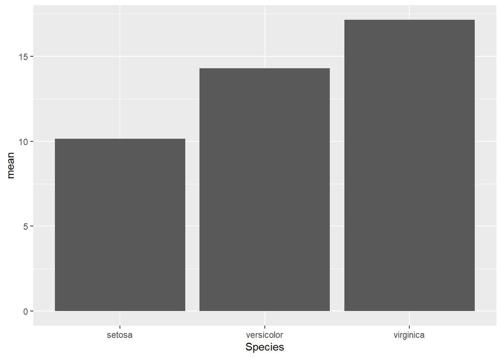

```r
# Plot basic barplot- effect of stat= "identity"
p=ggplot(df_sumzd,aes(x=Species,y=mean))+
   geom_bar(stat="identity")
p
```

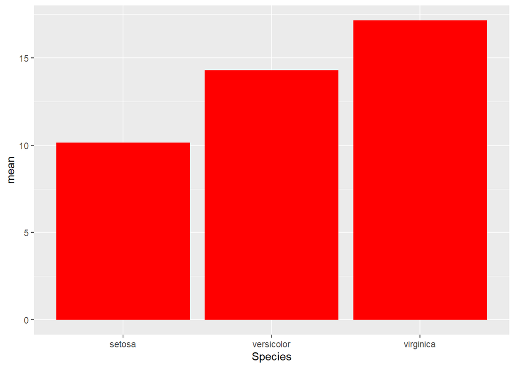

```r
# fill color
p=ggplot(df_sumzd,aes(x=Species,y=mean))+
   geom_bar(stat="identity",fill="red")
p
```

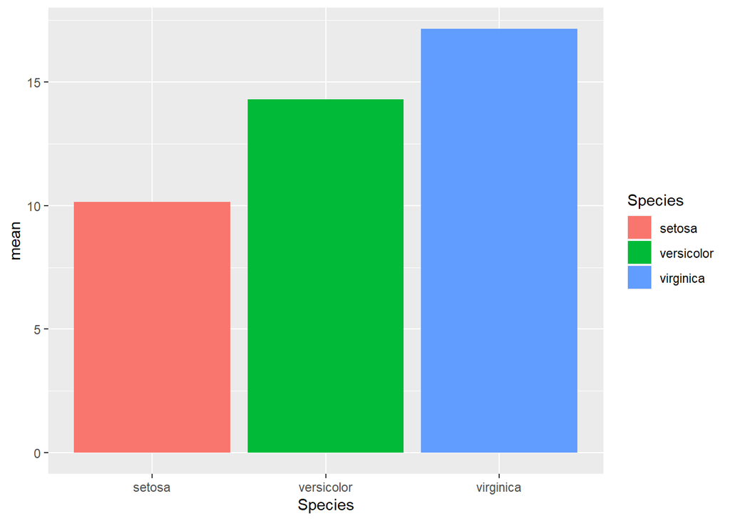

```r
p=ggplot(df_sumzd,aes(x=Species,y=mean, fill=Species))+
   geom_bar(stat="identity")
p
```

# Fill Color - mapping to a variable

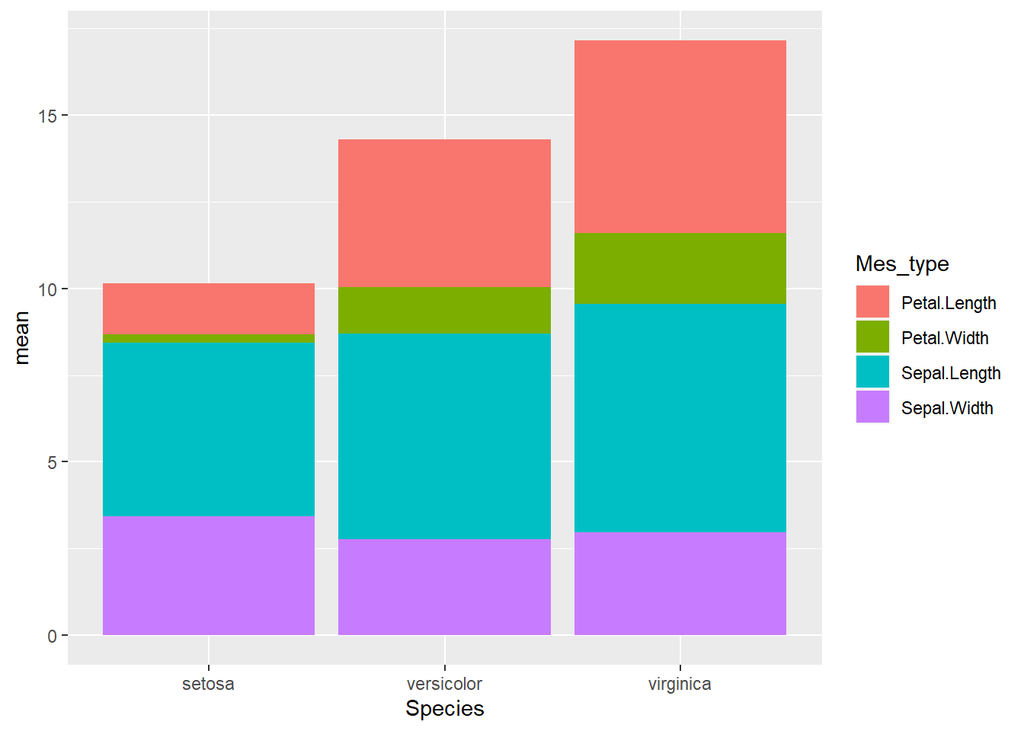

```r
# fill colors- stacked bar plot
p=ggplot(df_sumzd,aes(x=Species,y=mean,fill=Mes_type))+
   geom_bar(stat="identity")
p
```

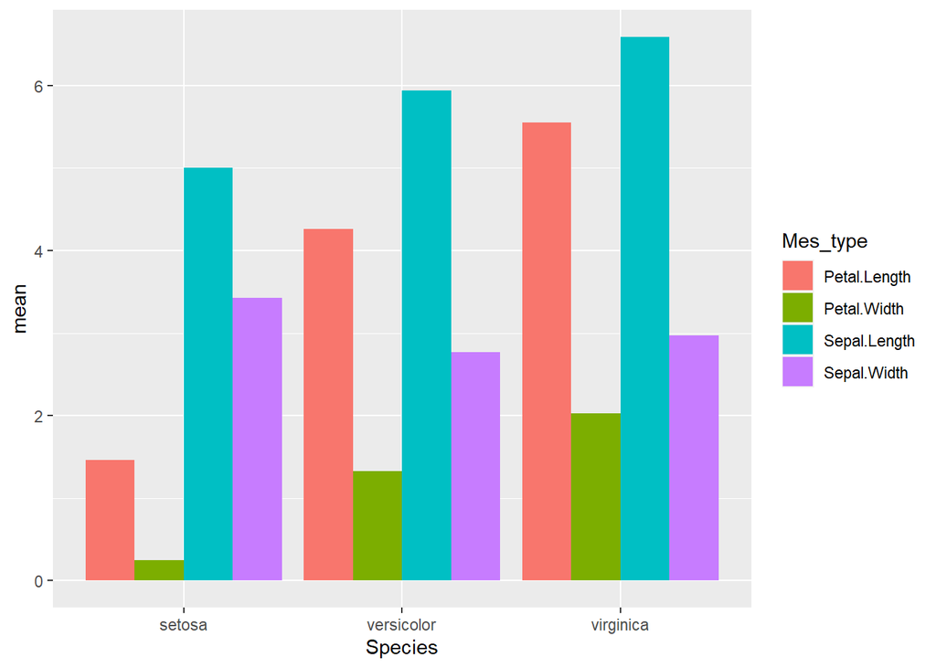

```r
# fill colors- grouped bar plot
p=ggplot(df_sumzd,aes(x=Species,y=mean,fill=Mes_type))+
   geom_bar(stat="identity",position="dodge")
p
```

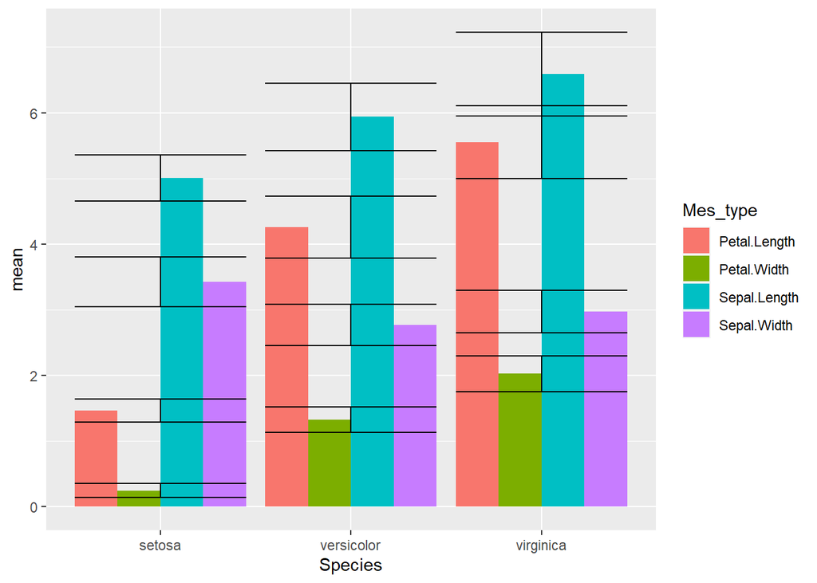

```r
#Error bars
p=ggplot(df_sumzd,aes(x=Species,y=mean,fill=Mes_type))+
   geom_bar(stat="identity",position="dodge") +
   geom_errorbar(aes(ymin=mean-sd,ymax=mean+sd))

p
```

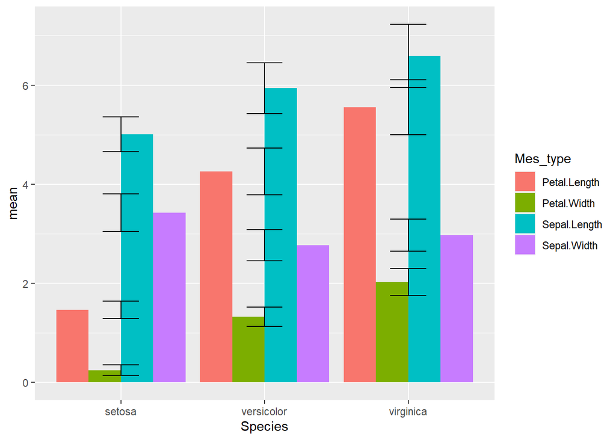

```r
#Error bars width
p=ggplot(df_sumzd,aes(x=Species,y=mean,fill=Mes_type))+
   geom_bar(stat="identity",position="dodge") +
   geom_errorbar(aes(ymin=mean-sd,ymax=mean+sd),width=0.25)

p
```

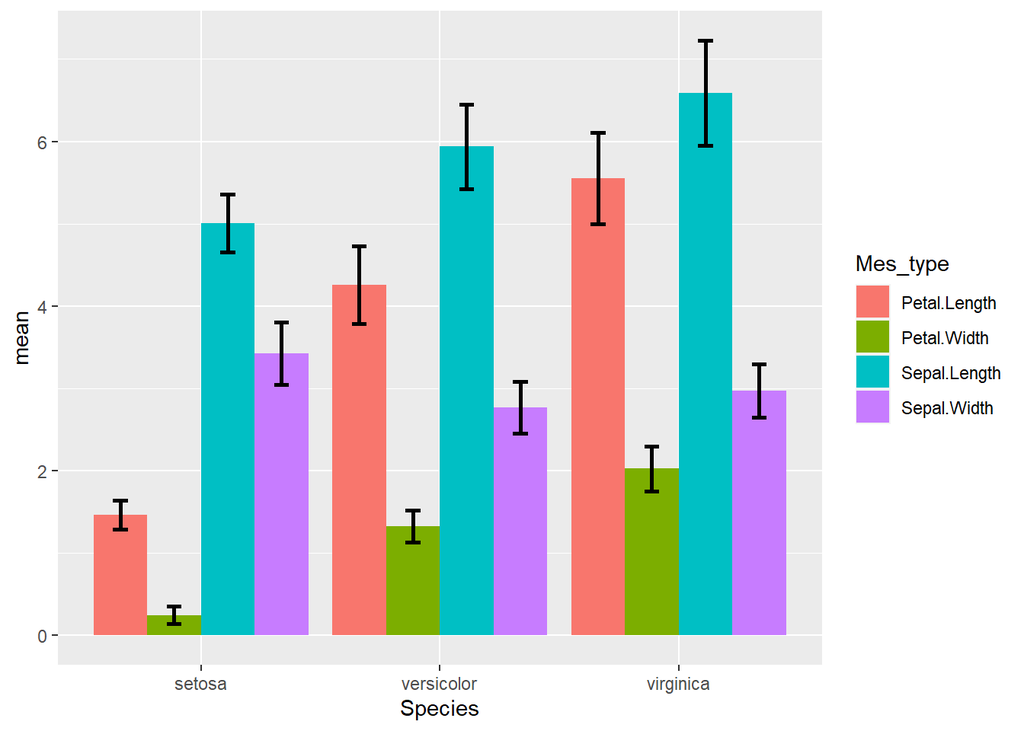

```r
#Error bars width, size,position
p=ggplot(df_sumzd,aes(x=Species,y=mean,fill=Mes_type))+
   geom_bar(stat="identity",position="dodge") +
   geom_errorbar(aes(ymin=mean-sd,ymax=mean+sd),width=0.25,
                 size=1,position= position_dodge(0.9))
p
```

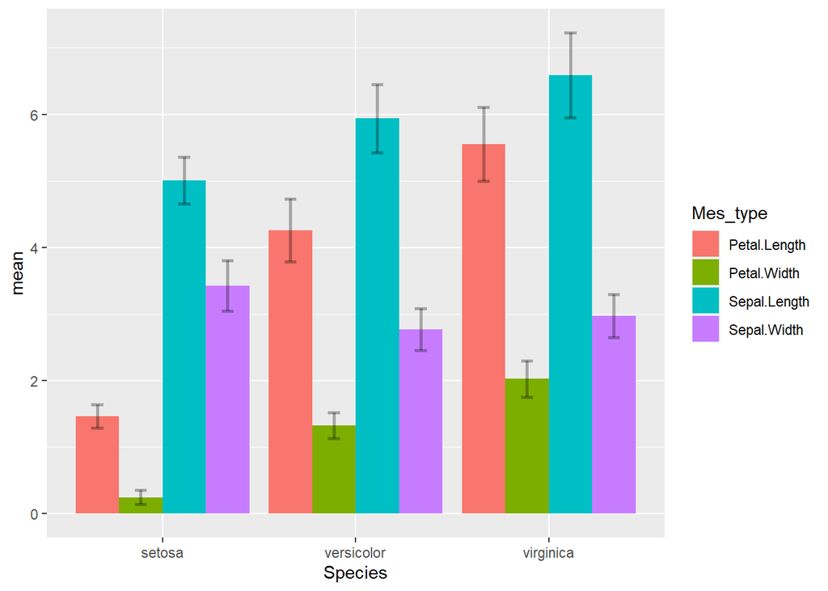

```r
#Error bars width,size, position, alpha
p=ggplot(df_sumzd,aes(x=Species,y=mean,fill=Mes_type))+
   geom_bar(stat="identity",position="dodge") +
   geom_errorbar(aes(ymin=mean-sd,ymax=mean+sd),width=0.25,
                 size=1,position= position_dodge(0.9),alpha=0.3)
p
```

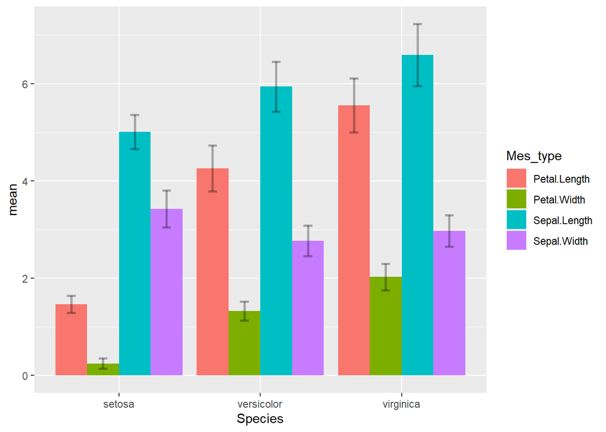

```r
#Error bars width,size, position, alpha and labels
p=ggplot(df_sumzd,aes(x=Species,y=mean,fill=Mes_type,label=mean))+
   geom_bar(stat="identity",position="dodge") +
   geom_errorbar(aes(ymin=mean-sd,ymax=mean+sd),width=0.25,
                 size=1,position= position_dodge(0.9), alpha=0.3)
p
```

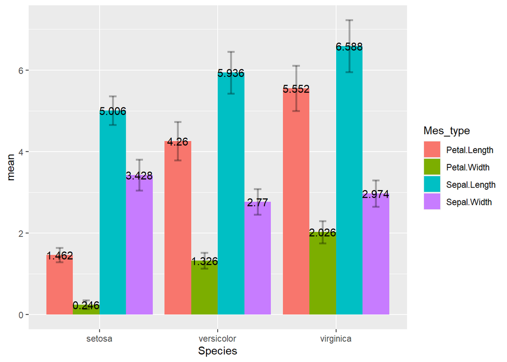

```r
#Error bars width,size, position, alpha and labels
p=ggplot(df_sumzd,aes(x=Species,y=mean,fill=Mes_type,label=mean))+
   geom_bar(stat="identity",position="dodge") +
   geom_errorbar(aes(ymin=mean-sd,ymax=mean+sd),width=0.25,
                 size=1,position= position_dodge(0.9), alpha=0.3)+
   geom_text(position=position_dodge(0.9))

p
```

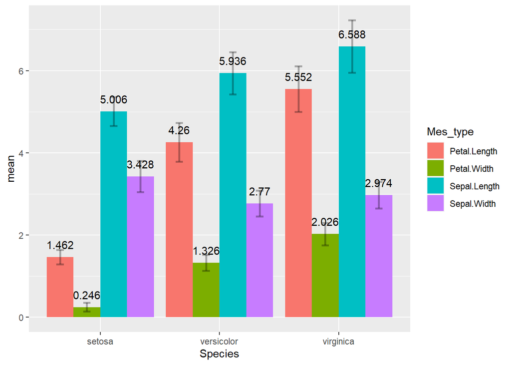

```r
#Error bars width,size, position, alpha and labels, label position corrected
p=ggplot(df_sumzd,aes(x=Species,y=mean,fill=Mes_type,label=mean))+
   geom_bar(stat="identity",position="dodge") +
   geom_errorbar(aes(ymin=mean-sd,ymax=mean+sd),width=0.25,
                 size=1,position= position_dodge(0.9), alpha=0.3)+
   geom_text(position=position_dodge(0.9),vjust=-1)

p
```

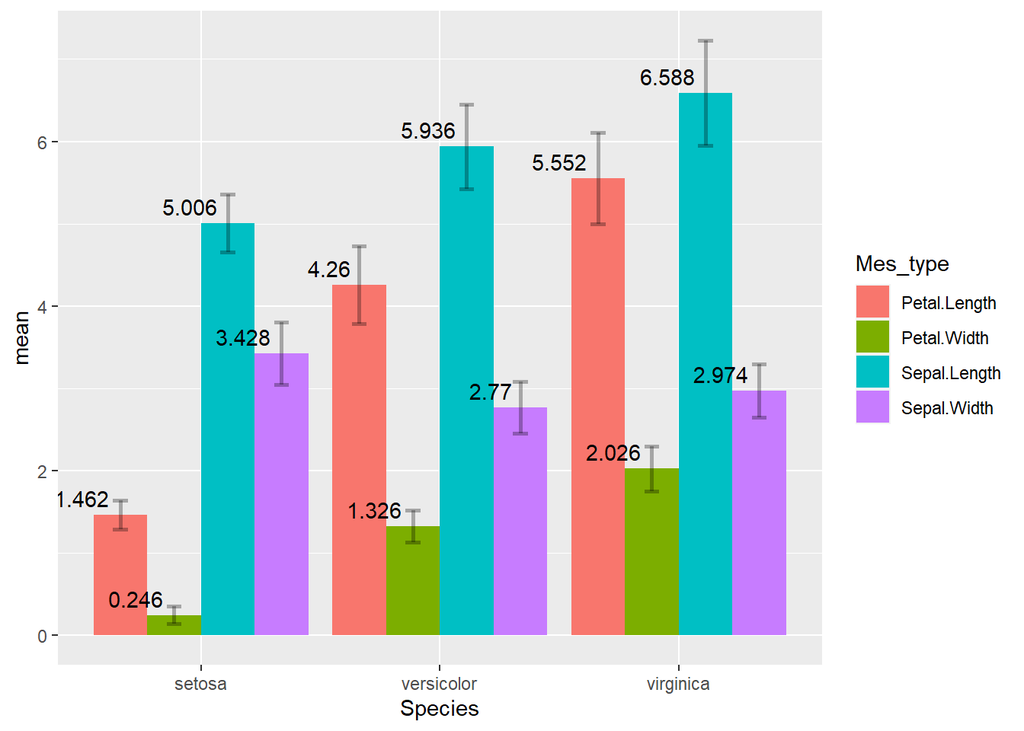

```r
#Error bars width,size, position, alpha and labels, label position more corrected
p=ggplot(df_sumzd,aes(x=Species,y=mean,fill=Mes_type,label=mean))+
   geom_bar(stat="identity",position="dodge") +
   geom_errorbar(aes(ymin=mean-sd,ymax=mean+sd),width=0.25,
                 size=1,position= position_dodge(0.9), alpha=0.3)+
   geom_text(position=position_dodge(0.9),vjust=-0.5, hjust=1.2)
p
```

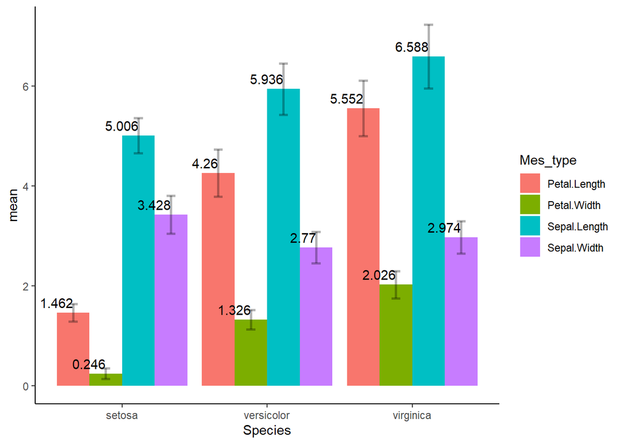

```r
#theme classic
p=ggplot(df_sumzd,aes(x=Species,y=mean,fill=Mes_type,label=mean))+
   geom_bar(stat="identity",position="dodge") +
   geom_errorbar(aes(ymin=mean-sd,ymax=mean+sd),width=0.25,
                 size=1,position= position_dodge(0.9), alpha=0.3)+
   geom_text(position=position_dodge(0.9),vjust=-0.5, hjust=1)+
   theme_classic()
p
```

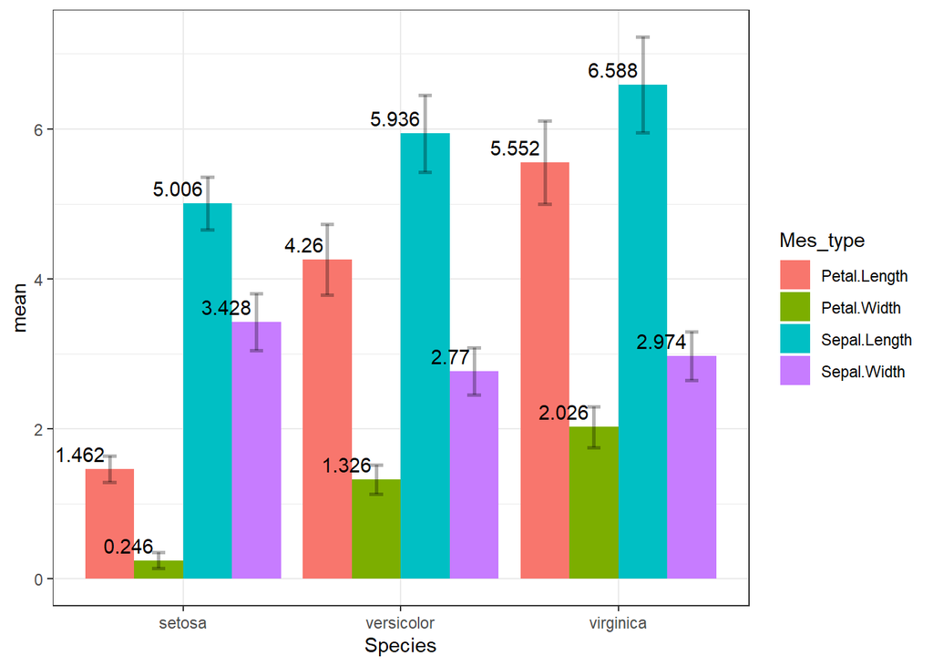

```r
#theme bw
p=ggplot(df_sumzd,aes(x=Species,y=mean,fill=Mes_type,label=mean))+
   geom_bar(stat="identity",position="dodge") +
   geom_errorbar(aes(ymin=mean-sd,ymax=mean+sd),width=0.25,
                 size=1,position= position_dodge(0.9), alpha=0.3)+
   geom_text(position=position_dodge(0.9),vjust=-0.5, hjust=1.1)+
   theme_bw()

p
```

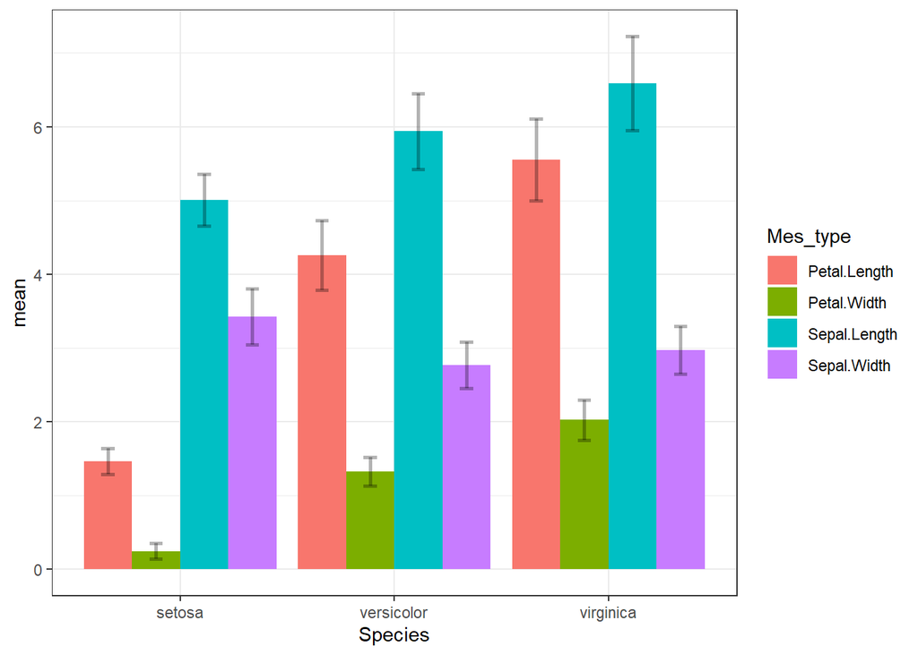

```r
# I don't like this plot.
p=ggplot(df_sumzd,aes(x=Species,y=mean,fill=Mes_type))+
   geom_bar(stat="identity",position="dodge") +
   geom_errorbar(aes(ymin=mean-sd,ymax=mean+sd),width=0.25,
                 size=1,position= position_dodge(0.9), alpha=0.3)+
      theme_bw()
p
```

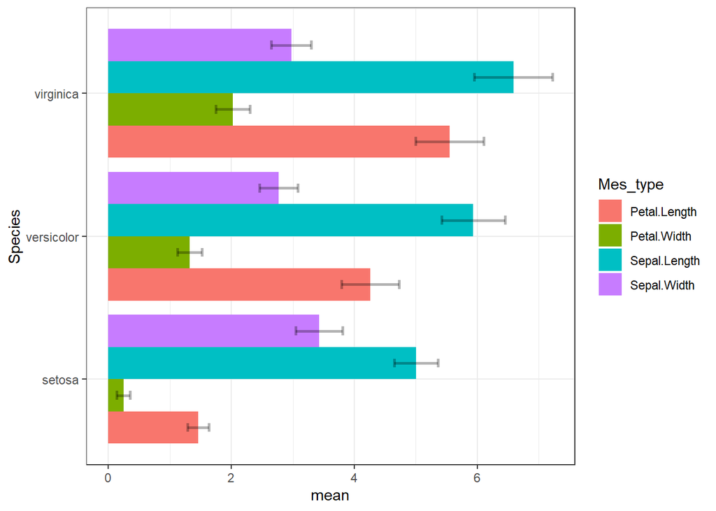

```r
# coord flip, this to when x axis labels are very long and overlap each other
p=ggplot(df_sumzd,aes(x=Species,y=mean,fill=Mes_type))+
   geom_bar(stat="identity",position="dodge") +
   geom_errorbar(aes(ymin=mean-sd,ymax=mean+sd),width=0.25,
                 size=1,position= position_dodge(0.9), alpha=0.3)+
   theme_bw()+
   coord_flip()
p
```

#That’s it for bar plot.

# Descriptive Statistics Using R

# Testing Hypothesis

## Test 1. Pearson Correlation Test

## T-Test

## Chi-Square Test

## ANOVA

# Other Parametric Tests

# Non-Parametic Tests